# Lab 05 - APIs and Web Scraping

```python
import pandas as pd
import numpy as np
import requests
from bs4 import BeautifulSoup
from io import StringIO
import re
import json
import time
from plotnine import *
import warnings
warnings.filterwarnings('ignore')
```

# Learning Goals

- Use a real-world API to make queries and process JSON data
- Handle API pagination to fetch large datasets
- Use web scraping to extract tables from Wikipedia
- Use regular expressions to clean scraped data
- Merge datasets from different sources
- Practice your GitHub skills

##### Download lab `.qmd` and dataset [here](https://github.com/JSC370/JSC370-2026/tree/main/labs/lab5)

# Deliverables

Upload your html and qmd to Quercus by 11:59 pm Wednesday February 4th, 2026.

# Lab Description

In this lab, we will practice using APIs and web scraping to obtain and combine movie data from different sources. We will use [The Movie Database (TMDB) API](https://developer.themoviedb.org/docs/getting-started) to fetch movie information and scrape the [Wikipedia page on Academy Award-winning films](https://en.wikipedia.org/wiki/List_of_Academy_Award%E2%80%93winning_films) to get Oscar data, just like in lecture!

**Before starting:** Sign up for a free TMDB API key at [themoviedb.org](https://www.themoviedb.org/settings/api). You’ll need it for Question 1.

## Question 1: Fetching movie data from the TMDB API

The TMDB API allows us to discover movies, get details, and search for films. The base URL is:

```
https://api.themoviedb.org/3
```

### 1a. Set up and discover movies

Replace `"YOUR_API_KEY"` with your actual TMDB API key. Then use the `/discover/movie` endpoint to find top-grossing movies.

Refer to the [TMDB Discover API docs](https://developer.themoviedb.org/reference/discover-movie) and fill in the query parameters below:

```python
# TMDB API configuration
BASE_URL = "https://api.themoviedb.org/3"
API_KEY = "2418706031b4f8c9803ae53f0c5f8372"  # Replace with your API key - For this lab we must push to github..

# Discover top-grossing movies
url = f"{BASE_URL}/discover/movie"

# YOUR CODE HERE: Fill in the query parameters
# - Sort by revenue in descending order
# - Start with page 1
params = {
    "api_key": API_KEY,
    "sort_by": "revenue.desc",
    "page": 1
}

response = requests.get(url, params=params, timeout=30)
print(f"Status Code: {response.status_code}")
print(f"Request URL: {response.url}")
```

```
Status Code: 200
Request URL: https://api.themoviedb.org/3/discover/movie?api_key=2418706031b4f8c9803ae53f0c5f8372&sort_by=revenue.desc&page=1
```

### 1b. Examine the JSON response

The API returns a JSON object. Parse it and explore its structure.

```python
data = response.json()
display(data)
# YOUR CODE HERE:
# 1. Print the total number of results (hint: data.get('total_results'))
total_num = data.get('total_results', 0)
# we use display instead of print, bc print treats everything as string.
# the 2nd parameter to get is what it will return instead of an error or None if it cant find the first key
display(total_num)


# 2. Print the total number of pages

display(data.get('total_pages', 0))

# 3. Print how many movies are on this page (first page) (hint: len(data.get('results', [])))
len(data.get('results', []))
```

[output not shown]

[output cut: 228 more lines]

[output not shown]

```
1100659
```

```
55033
```

```
20
```

### 1c. Fetch movie details and build a DataFrame

The `/discover/movie` endpoint returns basic info (id, title, popularity, vote_average), but not budget or revenue. To get those, we need to call the `/movie/{id}` endpoint for each movie.

First, collect movie IDs from multiple pages of discover results. Then fetch details for each movie. Build a DataFrame with the following columns: `movie_id`, `title`, `release_date`, `popularity`, `revenue`, `budget`, `vote_average`.

**Important:** Use `time.sleep(0.1)` between requests to respect rate limits.

#### Step 1: Get the movie IDs

```python
import math

# YOUR CODE HERE:
# The discover endpoint returns 20 movies per page.
# Calculate how many pages you need if you want to fetch 100 movies.
# Then loop through the pages, collecting movie IDs.

MOVIES_COUNT = 100
MOVIES_PER_PAGE = 20
n_pages = math.ceil(MOVIES_COUNT / MOVIES_PER_PAGE)

all_movie_ids = []

for page in range(1, n_pages+1):
    params = {
        "api_key": API_KEY,
        "sort_by": "revenue.desc",
        "page": page
    }
    # 1. Make the GET request
    response = requests.get(url, params=params, timeout=30)
    # 2. Parse the JSON response
    data = response.json()
    # 3. Extract the 'id' from each movie in results and append to all_movie_ids
    results = data.get('results', [])
    for movie in results:
        id = movie['id']
        all_movie_ids.append(id)

    # 4. Sleep for 0.1 seconds between requests
    time.sleep(0.1)

print(f"Collected {len(all_movie_ids)} movie IDs")
```

```
Collected 100 movie IDs
```

#### Step 2: For each movie ID, fetch details

```python
# YOUR CODE HERE:
# Loop through all_movie_ids and for each movie:
#   1. GET f"{BASE_URL}/movie/{mid}" with api_key param -> parse JSON
#   2. Append a dict with: movie_id, title, release_date, popularity,
#      revenue, budget, vote_average, genres
#      Hint: use detail.get('key') to safely extract each field
#   3. Sleep 0.25 seconds between requests
#   4. Optionally print progress every 20 movies

detailed_movies = []
for i, mid in enumerate(all_movie_ids):
    url = f"{BASE_URL}/movie/{mid}"
    params = {
        "api_key": API_KEY
    }
    response = requests.get(url, params=params, timeout=30)
    data = response.json()
    d = {
        'movie_id': mid,
        'title': data.get('title', ''),
        'release_data': data.get('release_date', ''),
        'popularity': data.get('popularity', 0),
        'revenue': data.get('revenue',0),
        'budget': data.get('budget',0),
        'vote_average': data.get('vote_average',0),
        'genres': data.get('genres',[])
    }
    detailed_movies.append(d)
    time.sleep(0.25)
    if i %20 ==0:
        print(f'Fetched {i}/100 movies')



df_movies = pd.DataFrame(detailed_movies)
print(f"Fetched details for {len(df_movies)} movies")
df_movies.head(10)
```

```
Fetched 0/100 movies
Fetched 20/100 movies
Fetched 40/100 movies
Fetched 60/100 movies
Fetched 80/100 movies
Fetched details for 100 movies
```

|  | movie_id | title | release_data | popularity | revenue | budget | vote_average | genres |
| --- | --- | --- | --- | --- | --- | --- | --- | --- |
| 0 | 19995 | Avatar | 2009-12-16 | 39.4260 | 2923706026 | 237000000 | 7.600 | [{'id': 28, 'name': 'Action'}, {'id': 12, 'nam... |
| 1 | 299534 | Avengers: Endgame | 2019-04-24 | 15.5834 | 2799439100 | 356000000 | 8.236 | [{'id': 12, 'name': 'Adventure'}, {'id': 878, ... |
| 2 | 76600 | Avatar: The Way of Water | 2022-12-14 | 36.0293 | 2353096253 | 350000000 | 7.600 | [{'id': 28, 'name': 'Action'}, {'id': 12, 'nam... |
| 3 | 597 | Titanic | 1997-12-18 | 30.7236 | 2264162353 | 200000000 | 7.902 | [{'id': 18, 'name': 'Drama'}, {'id': 10749, 'n... |
| 4 | 980477 | Ne Zha 2 | 2025-01-29 | 32.3843 | 2259822417 | 80000000 | 8.111 | [{'id': 16, 'name': 'Animation'}, {'id': 14, '... |
| 5 | 140607 | Star Wars: The Force Awakens | 2015-12-15 | 9.0032 | 2068223624 | 245000000 | 7.300 | [{'id': 12, 'name': 'Adventure'}, {'id': 28, '... |
| 6 | 299536 | Avengers: Infinity War | 2018-04-25 | 26.1459 | 2052415039 | 300000000 | 8.234 | [{'id': 12, 'name': 'Adventure'}, {'id': 28, '... |
| 7 | 634649 | Spider-Man: No Way Home | 2021-12-15 | 22.6142 | 1921847111 | 200000000 | 7.933 | [{'id': 28, 'name': 'Action'}, {'id': 12, 'nam... |
| 8 | 1084242 | Zootopia 2 | 2025-11-26 | 370.8550 | 1744338246 | 150000000 | 7.600 | [{'id': 16, 'name': 'Animation'}, {'id': 35, '... |
| 9 | 1022789 | Inside Out 2 | 2024-06-11 | 18.4380 | 1698863816 | 200000000 | 7.546 | [{'id': 16, 'name': 'Animation'}, {'id': 12, '... |

To save time, read in the saved dataset of 10,000 movies and do a summary so we know what to clean.

```python
df_movies = pd.read_csv("movies.csv")
df_movies.describe()
```

|  | movie_id | popularity | revenue | budget | vote_average |
| --- | --- | --- | --- | --- | --- |
| count | 1.000000e+04 | 10000.000000 | 1.000000e+04 | 1.000000e+04 | 10000.000000 |
| mean | 2.233297e+05 | 3.960426 | 8.040872e+07 | 2.508906e+07 | 6.421749 |
| std | 3.401565e+05 | 11.169887 | 1.636094e+08 | 4.012444e+07 | 1.119996 |
| min | 6.000000e+00 | 0.000000 | 4.678632e+06 | 0.000000e+00 | 0.000000 |
| 25% | 1.066075e+04 | 1.288800 | 1.064562e+07 | 1.000000e+06 | 5.963000 |
| 50% | 3.740150e+04 | 2.513550 | 2.514544e+07 | 1.029226e+07 | 6.525000 |
| 75% | 3.459385e+05 | 4.836425 | 7.612413e+07 | 3.000000e+07 | 7.087000 |
| max | 1.625321e+06 | 713.150600 | 2.923706e+09 | 5.839000e+08 | 10.000000 |

### 1d. Clean the data

Examine the data with `df_movies.describe()`. Look for variables with unrealistic values (e.g., budget of 0, extreme popularity values). Clean as needed and extract the year from `release_date`.

```python
# YOUR CODE HERE:
# 1. Examine the data with describe() to identify issues
display(df_movies.describe())
# 2. Remove movies with unrealistic values (e.g., budget == 0, extreme popularity)
display(df_movies[df_movies['budget']==0])
#there are 2171 rows, so we can drop
df_movies = df_movies[df_movies['budget']!=0]

display(df_movies[df_movies['popularity']>200])
# zootopia 2 has high popularity and it makes sense, so this seems okay.

# 3. Extract year from release_date
df_movies['year'] = pd.to_datetime(df_movies['release_date']).dt.year

# 4. Print how many movies remain
display(len(df_movies))
# We had 10000 movies originally, now we have 7829
```

|  | movie_id | popularity | revenue | budget | vote_average |
| --- | --- | --- | --- | --- | --- |
| count | 1.000000e+04 | 10000.000000 | 1.000000e+04 | 1.000000e+04 | 10000.000000 |
| mean | 2.233297e+05 | 3.960426 | 8.040872e+07 | 2.508906e+07 | 6.421749 |
| std | 3.401565e+05 | 11.169887 | 1.636094e+08 | 4.012444e+07 | 1.119996 |
| min | 6.000000e+00 | 0.000000 | 4.678632e+06 | 0.000000e+00 | 0.000000 |
| 25% | 1.066075e+04 | 1.288800 | 1.064562e+07 | 1.000000e+06 | 5.963000 |
| 50% | 3.740150e+04 | 2.513550 | 2.514544e+07 | 1.029226e+07 | 6.525000 |
| 75% | 3.459385e+05 | 4.836425 | 7.612413e+07 | 3.000000e+07 | 7.087000 |
| max | 1.625321e+06 | 713.150600 | 2.923706e+09 | 5.839000e+08 | 10.000000 |

|  | movie_id | title | release_date | popularity | revenue | budget | vote_average | genres |
| --- | --- | --- | --- | --- | --- | --- | --- | --- |
| 57 | 1624041 | Untitled | 2025-09-27 | 0.3997 | 1000000000 | 0 | 5.000 | [] |
| 166 | 1066298 | Full River Red | 2023-01-22 | 1.4041 | 673556758 | 0 | 5.964 | [{'id': 9648, 'name': 'Mystery'}, {'id': 35, '... |
| 183 | 1239561 | Waffle F1 - The Movie | 2022-05-11 | 0.0434 | 631742436 | 0 | 0.000 | [{'id': 18, 'name': 'Drama'}, {'id': 28, 'name... |
| 265 | 1357305 | Detective Chinatown 1900 | 2025-01-29 | 2.3223 | 500282092 | 0 | 6.269 | [{'id': 35, 'name': 'Comedy'}, {'id': 9648, 'n... |
| 266 | 1462748 | DUDURITMUS | NaN | 0.0000 | 500000000 | 0 | 0.000 | [] |
| ... | ... | ... | ... | ... | ... | ... | ... | ... |
| 9989 | 94965 | Okkadu | 2003-01-15 | 0.5403 | 4693170 | 0 | 7.300 | [{'id': 28, 'name': 'Action'}, {'id': 18, 'nam... |
| 9990 | 13280 | Kickin' It Old Skool | 2007-04-27 | 1.0436 | 4692108 | 0 | 4.706 | [{'id': 35, 'name': 'Comedy'}] |
| 9995 | 791333 | Four's a Crowd | 2022-10-28 | 3.9497 | 4683403 | 0 | 6.292 | [{'id': 35, 'name': 'Comedy'}] |
| 9998 | 243544 | K3: Animal Hotel | 2014-02-12 | 0.2587 | 4679370 | 0 | 7.400 | [{'id': 10751, 'name': 'Family'}, {'id': 35, '... |
| 9999 | 268642 | Delete My Love | 2014-05-08 | 5.9712 | 4678632 | 0 | 6.600 | [{'id': 35, 'name': 'Comedy'}] |

2171 rows × 8 columns

|  | movie_id | title | release_date | popularity | revenue | budget | vote_average | genres |
| --- | --- | --- | --- | --- | --- | --- | --- | --- |
| 8 | 1084242 | Zootopia 2 | 2025-11-26 | 428.3987 | 1744338246 | 150000000 | 7.600 | [{'id': 16, 'name': 'Animation'}, {'id': 35, '... |
| 1532 | 1234731 | Anaconda | 2025-12-24 | 287.9495 | 131241811 | 45000000 | 6.000 | [{'id': 12, 'name': 'Adventure'}, {'id': 35, '... |
| 7279 | 840464 | Greenland 2: Migration | 2026-01-07 | 713.1506 | 11416907 | 90000000 | 6.493 | [{'id': 12, 'name': 'Adventure'}, {'id': 53, '... |

```
7829
```

## Question 2: Scraping Oscar data from Wikipedia

Now let’s scrape the [List of Academy Award-winning films](https://en.wikipedia.org/wiki/List_of_Academy_Award%E2%80%93winning_films) from Wikipedia, just like in lecture.

### 2a. Fetch and parse the Wikipedia page

Look at what tables are on this website.

```python
OSCARS_URL = "https://en.wikipedia.org/wiki/List_of_Academy_Award%E2%80%93winning_films"

# Include headers to identify ourselves
HEADERS = {
    "User-Agent": "jsc370-class-project/1.0 (educational use)",
    "Accept-Language": "en-US,en;q=0.9",
}

# Fetch the page
oscars_request = requests.get(OSCARS_URL, headers=HEADERS, timeout=30)
print(f"Status code: {oscars_request.status_code}")

# Parse all tables
osc_tables = pd.read_html(StringIO(oscars_request.text))
print(f"Found {len(osc_tables)} tables")

# Examine the tables to find the right one
for i, table in enumerate(osc_tables):
    print(f"\nTable {i}: {table.shape[0]} rows x {table.shape[1]} cols")
    print(f"  Columns: {table.columns.tolist()}")
```

```
Status code: 200
Found 2 tables

Table 0: 1387 rows x 4 cols
  Columns: ['Film', 'Year', 'Awards', 'Nominations']

Table 1: 10 rows x 2 cols
  Columns: ['vteAcademy Awards lists', 'vteAcademy Awards lists.1']
```

### 2b. Extract the main Oscar winners table

Extract the first table on the website, summarize the data you get.

```python
# YOUR CODE HERE: Select the correct table index based on the output above
# The main table should have columns like: Film, Year, Awards, Nominations

osc = osc_tables[0]
print(f"Shape: {osc.shape}")
osc.head(10)
```

```
Shape: (1387, 4)
```

|  | Film | Year | Awards | Nominations |
| --- | --- | --- | --- | --- |
| 0 | Anora | 2024 | 5 | 6 |
| 1 | The Brutalist | 2024 | 3 | 10 |
| 2 | Emilia Pérez | 2024 | 2 | 13 |
| 3 | Wicked | 2024 | 2 | 10 |
| 4 | Dune: Part Two | 2024 | 2 | 5 |
| 5 | Conclave | 2024 | 1 | 8 |
| 6 | The Substance | 2024 | 1 | 5 |
| 7 | I'm Still Here | 2024 | 1 | 3 |
| 8 | Flow | 2024 | 1 | 2 |
| 9 | A Real Pain | 2024 | 1 | 2 |

Check variable types to see if we need to clean.

```python
# YOUR CODE HERE: Check the dtypes of the Oscar table
# Hint: osc.dtypes
```

[output not shown]

### 2c. Clean the columns using regular expressions

Make `Year`, `Awards`, and `Nominations` numeric. You may need to remove footnotes like `[1]` and handle strings like `2020/21`.

Use regex to extract just the 4-digit `Year` and integers for `Awards` and `Nominations`.

```python
# YOUR CODE HERE:
# For each of Year, Awards, Nominations:
#   1. Convert to string
#   2. Remove wiki-style footnotes like [2], [10] using .str.replace()
#   3. Extract the first number using .str.extract()
#   4. Convert to numeric with pd.to_numeric()

osc['Year']= osc['Year'].astype(str).replace(r'/\d+', '', regex=True).astype(int)
osc['Awards'] = osc['Awards'].astype(str).replace(r'\(\d+\)|\[\d+\]', '', regex = True).str.strip().astype(int)

osc['Nominations'] = osc['Nominations'].astype(str).replace(r'\(\d+\)|\[\d+\]', '', regex = True).str.strip().astype(int)
# Verify the dtypes after cleaning
display(osc['Year'].unique())
display(osc['Awards'].unique())
display(osc['Nominations'].unique())
osc.dtypes
```

```
array([2024, 2023, 2022, 2021, 2020, 2019, 2018, 2017, 2016, 2015, 2014,
       2013, 2012, 2011, 2010, 2009, 2008, 2007, 2006, 2005, 2004, 2003,
       2002, 2001, 2000, 1999, 1998, 1997, 1996, 1995, 1994, 1993, 1992,
       1991, 1990, 1989, 1988, 1987, 1986, 1985, 1984, 1983, 1982, 1981,
       1980, 1979, 1978, 1977, 1976, 1975, 1974, 1973, 1972, 1971, 1970,
       1969, 1968, 1967, 1966, 1965, 1964, 1927, 1954, 1949, 1938, 1951,
       1943, 1960, 1953, 1957, 1950, 1929, 1941, 1958, 1963, 1956, 1945,
       1946, 1936, 1940, 1937, 1947, 1952, 1931, 1942, 1959, 1948, 1962,
       1961, 1928, 1955, 1935, 1939, 1932, 1930, 1934, 1944])
```

```
array([ 5,  3,  2,  1,  7,  4,  6,  0,  8, 11,  9, 10])
```

```
array([ 6, 10, 13,  5,  8,  3,  2,  1, 11,  9,  4,  7, 12,  0, 14])
```

```
Film           object
Year            int32
Awards          int32
Nominations     int32
dtype: object
```

### 2d. Explore the Oscar data

Do some summary statistics on the scraped Oscar data.

```python
# YOUR CODE HERE:
# 1. Do a general summary with describe()
display(osc.describe())
# 2. How many films are in the Oscar dataset?
display(len(osc))
# 3. What is the range of years?
display(osc['Year'].min(), osc['Year'].max())
# 4. What film has the most Awards?
display(osc[osc['Awards']==osc['Awards'].max()])
# 5. What is the average number of nominations?
display(osc['Nominations'].mean())
```

|  | Year | Awards | Nominations |
| --- | --- | --- | --- |
| count | 1387.000000 | 1387.000000 | 1387.000000 |
| mean | 1976.350397 | 1.573901 | 3.619322 |
| std | 27.699346 | 1.389814 | 3.136275 |
| min | 1927.000000 | 0.000000 | 0.000000 |
| 25% | 1952.000000 | 1.000000 | 1.000000 |
| 50% | 1976.000000 | 1.000000 | 2.000000 |
| 75% | 2001.000000 | 2.000000 | 5.500000 |
| max | 2024.000000 | 11.000000 | 14.000000 |

```
1387
```

```
1927
```

```
2024
```

|  | Film | Year | Awards | Nominations |
| --- | --- | --- | --- | --- |
| 310 | The Lord of the Rings: The Return of the King | 2003 | 11 | 11 |
| 392 | Titanic | 1997 | 11 | 14 |
| 882 | Ben-Hur | 1959 | 11 | 12 |

```
3.619322278298486
```

## Question 3: Merging TMDB movies with Oscar data

Now let’s combine the TMDB movie data from Question 1 with the scraped Oscar data from Question 2. We want to do a **left join** that keeps all TMDB movies and adds Oscar award information where available.

### 3a. Prepare both datasets for merging

Before merging, make sure the title and year columns are clean and compatible across both datasets.

```python
# YOUR CODE HERE:
# 1. Make sure df_movies has a clean year column
display(df_movies['year'].unique())
# it looks good already.
# 2. Check the columns we'll merge on
display(df_movies[['title']].head())
# 3. Preview what we're merging (number of rows in each)
display(len(df_movies))
display(len(osc))
# 4. Look at a few titles from each to check formatting
display(osc['Film'].head(10))
```

```
array([2009., 2019., 2022., 1997., 2025., 2015., 2018., 2021., 2024.,
       2012., 2023., 2011., 2017., 2013., 2016., 2003., 2014., 2010.,
       2006., 2008.,   nan, 2001., 2007., 2004., 2002., 1999., 1993.,
       2005., 1996., 1982., 1977., 1994., 1983., 1998., 2000., 1980.,
       2020., 1991., 1990., 1992., 1989., 1975., 1973., 1939., 1995.,
       1978., 1981., 1985., 1967., 1986., 1988., 1984., 1987., 1961.,
       1965., 1942., 1950., 1972., 1979., 1970., 1938., 1940., 1959.,
       1964., 1956., 1974., 1976., 1971., 1954., 1962., 1969., 1953.,
       1963., 1968., 1946., 1960., 1951., 2026., 1957., 1966., 1958.,
       1955., 1952., 1941., 1925., 1943., 1931., 1949., 1945., 1915.,
       1933., 1948., 2027., 1918., 1916., 1930., 1947., 1944., 1928.,
       1927., 1921., 1936., 1937.])
```

|  | title |
| --- | --- |
| 0 | Avatar |
| 1 | Avengers: Endgame |
| 2 | Avatar: The Way of Water |
| 3 | Titanic |
| 4 | Ne Zha 2 |

```
7829
```

```
1387
```

```
0             Anora
1     The Brutalist
2      Emilia Pérez
3            Wicked
4    Dune: Part Two
5          Conclave
6     The Substance
7    I'm Still Here
8              Flow
9       A Real Pain
Name: Film, dtype: object
```

### 3b. Merge the datasets

Perform a left join to keep all TMDB movies and add the Awards and Nominations columns from the Oscar data. Fill missing awards with 0 (movies that didn’t win any Oscars).

```python
# YOUR CODE HERE:
# 1. Left join df_movies with osc on title and year
#    Hint: df_movies has 'title' and 'year', osc has 'Film' and 'Year'
merged = pd.merge(df_movies, osc, how = 'left', left_on = ['title', 'year'], right_on = ['Film', 'Year'])
# 2. Fill missing Awards and Nominations with 0
merged['Awards'] = merged['Awards'].fillna(0).astype(int)
merged['Nominations'] = merged['Nominations'].fillna(0).astype(int)
# 3. Create an indicator for whether the movie won any Oscars
merged['won_oscar'] = merged['Awards'] > 0
# 4. Print summary of the merge (total movies, Oscar winners, non-winners)
display(len(merged))
display(len(merged[merged['won_oscar']]))
display(len(merged[~merged['won_oscar']]))
```

```
7829
```

```
549
```

```
7280
```

### 3c. Examine the merged data

```python
# YOUR CODE HERE:
# 1. Show the Oscar-winning movies in the dataset
display(merged[merged['won_oscar']])
# 2. Compare average budget and revenue for Oscar winners vs non-winners
display(merged[merged['won_oscar']][['budget', 'revenue']].mean())
display(merged[~merged['won_oscar']][['budget', 'revenue']].mean())
# 3. Which Oscar-winning movie had the highest revenue? Highest budget?
won_osc = merged[merged['won_oscar']]
display(won_osc[won_osc['revenue']==won_osc['revenue'].max()])
display(won_osc[won_osc['budget']==won_osc['budget'].max()])
```

|  | movie_id | title | release_date | popularity | revenue | budget | vote_average | genres | year | Film | Year | Awards | Nominations | won_oscar |
| --- | --- | --- | --- | --- | --- | --- | --- | --- | --- | --- | --- | --- | --- | --- |
| 0 | 19995 | Avatar | 2009-12-16 | 40.8368 | 2923706026 | 237000000 | 7.600 | [{'id': 28, 'name': 'Action'}, {'id': 12, 'nam... | 2009.0 | Avatar | 2009.0 | 3 | 9 | True |
| 2 | 76600 | Avatar: The Way of Water | 2022-12-14 | 36.5326 | 2353096253 | 350000000 | 7.600 | [{'id': 28, 'name': 'Action'}, {'id': 12, 'nam... | 2022.0 | Avatar: The Way of Water | 2022.0 | 1 | 4 | True |
| 3 | 597 | Titanic | 1997-12-18 | 32.0289 | 2264162353 | 200000000 | 7.900 | [{'id': 18, 'name': 'Drama'}, {'id': 10749, 'n... | 1997.0 | Titanic | 1997.0 | 11 | 14 | True |
| 14 | 361743 | Top Gun: Maverick | 2022-05-21 | 18.2251 | 1488732821 | 170000000 | 8.157 | [{'id': 28, 'name': 'Action'}, {'id': 18, 'nam... | 2022.0 | Top Gun: Maverick | 2022.0 | 1 | 6 | True |
| 16 | 346698 | Barbie | 2023-07-19 | 19.0413 | 1447138421 | 145000000 | 6.900 | [{'id': 35, 'name': 'Comedy'}, {'id': 12, 'nam... | 2023.0 | Barbie | 2023.0 | 1 | 8 | True |
| ... | ... | ... | ... | ... | ... | ... | ... | ... | ... | ... | ... | ... | ... | ... |
| 7710 | 25392 | Destination Moon | 1950-06-27 | 2.7474 | 5000000 | 592000 | 5.887 | [{'id': 878, 'name': 'Science Fiction'}, {'id'... | 1950.0 | Destination Moon | 1950.0 | 1 | 2 | True |
| 7724 | 599 | Sunset Boulevard | 1950-08-10 | 3.8840 | 5000000 | 1752000 | 8.285 | [{'id': 18, 'name': 'Drama'}] | 1950.0 | Sunset Boulevard | 1950.0 | 3 | 11 | True |
| 7744 | 16535 | Titanic | 1953-04-11 | 7.5903 | 4905000 | 1805000 | 6.600 | [{'id': 18, 'name': 'Drama'}, {'id': 10749, 'n... | 1953.0 | Titanic | 1953.0 | 1 | 2 | True |
| 7767 | 8342 | No Man's Land | 2001-05-12 | 1.1125 | 4858869 | 1012153 | 7.493 | [{'id': 28, 'name': 'Action'}, {'id': 36, 'nam... | 2001.0 | No Man's Land | 2001.0 | 1 | 1 | True |
| 7788 | 43266 | How Green Was My Valley | 1941-10-28 | 1.0465 | 4800000 | 800000 | 7.307 | [{'id': 18, 'name': 'Drama'}] | 1941.0 | How Green Was My Valley | 1941.0 | 5 | 10 | True |

549 rows × 14 columns

```
budget     3.681704e+07
revenue    1.986989e+08
dtype: float64
```

```
budget     3.168655e+07
revenue    8.728474e+07
dtype: float64
```

|  | movie_id | title | release_date | popularity | revenue | budget | vote_average | genres | year | Film | Year | Awards | Nominations | won_oscar |
| --- | --- | --- | --- | --- | --- | --- | --- | --- | --- | --- | --- | --- | --- | --- |
| 0 | 19995 | Avatar | 2009-12-16 | 40.8368 | 2923706026 | 237000000 | 7.6 | [{'id': 28, 'name': 'Action'}, {'id': 12, 'nam... | 2009.0 | Avatar | 2009.0 | 3 | 9 | True |

|  | movie_id | title | release_date | popularity | revenue | budget | vote_average | genres | year | Film | Year | Awards | Nominations | won_oscar |
| --- | --- | --- | --- | --- | --- | --- | --- | --- | --- | --- | --- | --- | --- | --- |
| 2 | 76600 | Avatar: The Way of Water | 2022-12-14 | 36.5326 | 2353096253 | 350000000 | 7.6 | [{'id': 28, 'name': 'Action'}, {'id': 12, 'nam... | 2022.0 | Avatar: The Way of Water | 2022.0 | 1 | 4 | True |

## Question 4: Visualize the results

### 4a. Compare revenue for Oscar winners vs non-winners

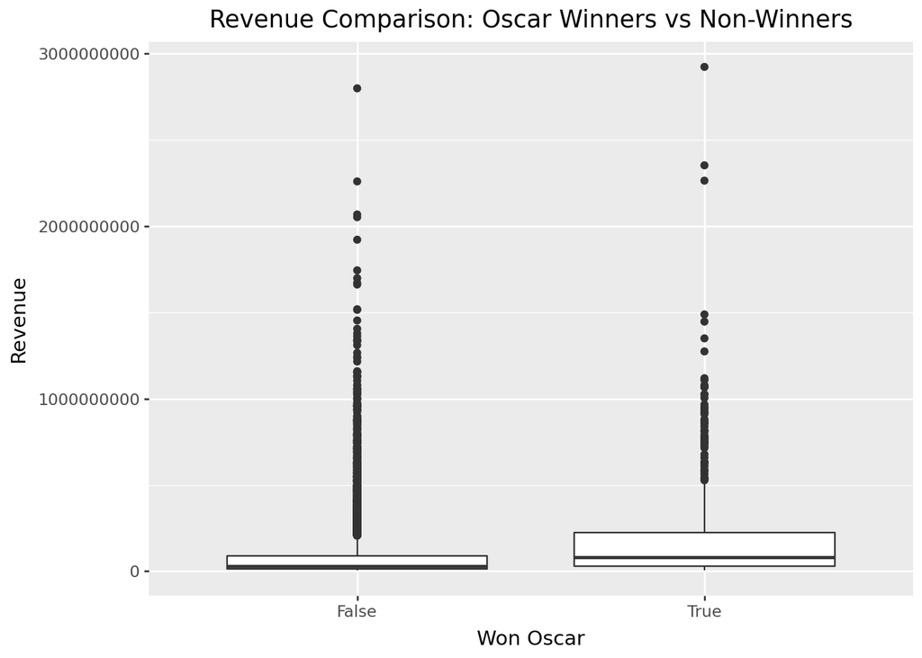

```python
# YOUR CODE HERE: Create a boxplot with plotnine comparing TMDB revenue
(
    ggplot(merged, aes(x='won_oscar', y='revenue')) +
    geom_boxplot()+
    labs(
        title="Revenue Comparison: Oscar Winners vs Non-Winners",
        x="Won Oscar",
        y="Revenue"
    )
)
# for Oscar winners vs non-winners
```

Summary: The revenue for oscar winners has a higher min, median, and max compared to non oscar winners. Non oscar winners do have a few that have a very high revenue, but overall oscar winners seem to do better in revenue.

### 4b. Scatter plot of budget vs revenue colored by Oscar status

TMDB provides budget data that Wikipedia doesn’t have, so we can explore the budget-revenue relationship.

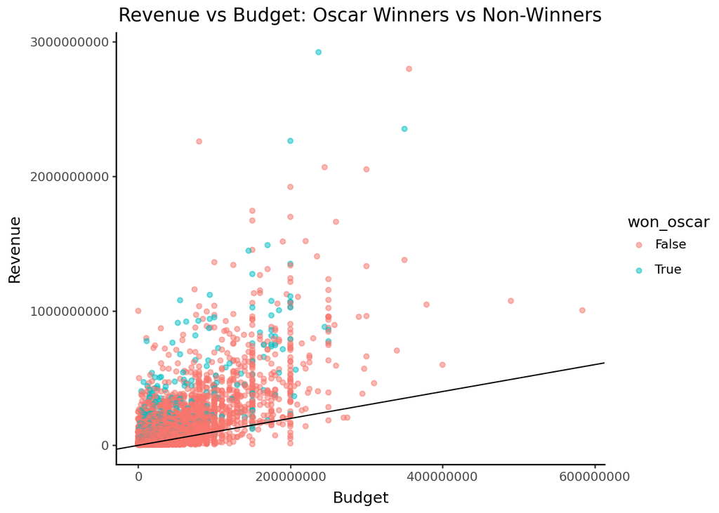

```python
# YOUR CODE HERE: Create a scatter plot with plotnine
(
    ggplot(merged, aes(x='budget', y='revenue', color='won_oscar')) +
    geom_point(alpha=0.5)+
    labs(
        title="Revenue vs Budget: Oscar Winners vs Non-Winners",
        x="Budget",
        y="Revenue"
    ) +
    geom_abline(slope=1, intercept=0) +
    theme_classic()
)
# - x-axis: budget
# - y-axis: revenue
# - Color by won_oscar
# - Consider adding geom_abline(slope=1, intercept=0) to show the break-even line
# - Add labels and title
```

Summary: Since most of the points are on top of the break even line, most movies have a revenue higher than budget. There are a few movies that are below the line and they are mostly non oscar winners, but there seems to be a one that WAS an oscar winner.

### 4c. Return on investment

Calculate the return on investment (revenue / budget) and compare Oscar winners vs non-winners.

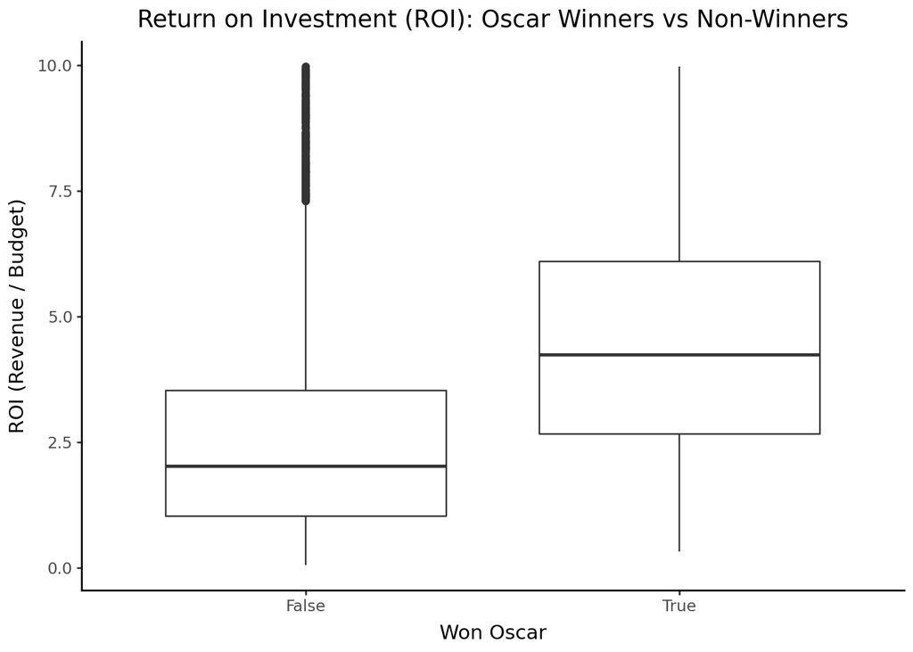

```python
# YOUR CODE HERE:
# 1. Calculate ROI: merged['roi'] = merged['revenue'] / merged['budget']
# 2. Create a boxplot or histogram comparing ROI for Oscar winners vs non-winners
# 3. What do you observe?

merged['roi'] = merged['revenue'] / merged['budget']

(
    ggplot(merged[merged['roi'] < 10], aes(x='won_oscar', y='roi')) +
    geom_boxplot()+
    labs(
        title="Return on Investment (ROI): Oscar Winners vs Non-Winners",
        x="Won Oscar",
        y="ROI (Revenue / Budget)"
    )+
    theme_classic()

)
```

## Summary: After restricting the scale, Oscar winners tend to have a higher ROI compared to non-winners. This suggests that winning an Oscar may positively impact a movie’s financial success relative to its budget.